# Final Project

Owen Atkins

2024-05-15

## Abstract

NEON Science is one of the leading companies in ecological research. They have collected a multitude of data on many different field sites on a plethora of bacteria. One site of interest was Healy, Alaska, and a bacterial phylum of interest was Planctomycetota. This project aimed to analyze the NEON data with a particular fixation to the Healy site and the phylum Planctomycetota using the Posit Cloud and R Studio software.

## Motivating Reasons

The Healy site is currently undergoing permafrost thawing as a consequence of human-induced climate change. Permafrost thawing has a massive impact on northern environments, causing the soil to loose its ability to support plants (Osterkamp et al. 2009). An additional consequence of permafrost thawing is that it can release dormant pathogens into the environment, which can have a devastating effect on both the wildlife and us humans.

Bacteria in the phylum Planctomycetota are currently the topic of study for many biotechnology companies, as they can be a source of bioactive molecules. These molecules are crucial to current research regarding treatments such as bioactive glass. In addition, bacteria in this phylum also play a key role in carbon and nitrogen cycles, making them a topic of interest for ecological research as well.

## Introduction

Healy is a NEON field site located on the northern border of Denali National Park, Alaska (“Healy NEON NSF NEON Open Data to Understand Our Ecosystems” n.d.). This site is composed mostly of taiga, with mean annual temperatures around -1.3 degrees Celsius, with the main vegetation present being shrubs and sedge meadows. The site sits at an elevation of 678 meters in a glaciated valley, and as recently been subject to permafrost thawing.

Planctomycetota is a bacterial phylum which are found regularly in both terrestrial and aquatic environments (“Planctomycetota” 2024). They are typically small, spherical cells that tend to associate with other organisms to form biological films, such as in algae and sponges.

## Methods

Data collected by NEON researchers was meticulously analyzed using Posit Cloud and R Studio software. Particular attention was paid to the data coming from the Healy NEON site, and to data regarding bacteria of the phylum Planctomycetota. Unrelated data was filtered out. The Posit Cloud software was then used to create and display several different graphs and tables to make the data more accessible.

## Results

```r
if (!require("BiocManager", quietly = TRUE))
    install.packages("BiocManager")
BiocManager::install("treeio")
BiocManager::install("ggtreeExtra")
if (!require("stringi", quietly = TRUE))
  install.packages("stringi")
```

```r
library(tidyverse)
library(knitr)
library(ggtree)
```

```r
library(TDbook)
library(ggimage)
library(rphylopic)
library(treeio)
library(tidytree)
library(ape)
library(TreeTools)
library(phytools)
library(ggnewscale)
library(ggtreeExtra)
library(ggstar)
library(stringi)
```

```r
NEON_MAGs <- read_csv("data/NEON/GOLD_Study_ID_Gs0161344_NEON_2024_4_21.csv") %>%
  select(-c(`GOLD Study ID`, `Bin Methods`, `Created By`, `Date Added`, `Bin Lineage`)) %>%
  mutate("Assembly Type" = case_when(`Genome Name` == "NEON combined assembly" ~ `Genome Name`,
                            TRUE ~ "Individual")) %>%
  mutate_at("Assembly Type", str_replace, "NEON combined assembly", "Combined") %>%
  mutate_at("GTDB-Tk Taxonomy Lineage", str_replace, "d__", "") %>%
  mutate_at("GTDB-Tk Taxonomy Lineage", str_replace, "p__", "") %>%
  mutate_at("GTDB-Tk Taxonomy Lineage", str_replace, "c__", "") %>%
  mutate_at("GTDB-Tk Taxonomy Lineage", str_replace, "o__", "") %>%
  mutate_at("GTDB-Tk Taxonomy Lineage", str_replace, "f__", "") %>%
  mutate_at("GTDB-Tk Taxonomy Lineage", str_replace, "g__", "") %>%
  mutate_at("GTDB-Tk Taxonomy Lineage", str_replace, "s__", "") %>%
  separate(`GTDB-Tk Taxonomy Lineage`, c("Domain", "Phylum", "Class", "Order", "Family", "Genus", "Species"), ";", remove = FALSE) %>%
  mutate_at("Domain", na_if,"") %>%
  mutate_at("Phylum", na_if,"") %>%
  mutate_at("Class", na_if,"") %>%
  mutate_at("Order", na_if,"") %>%
  mutate_at("Family", na_if,"") %>%
  mutate_at("Genus", na_if,"") %>%
  mutate_at("Species", na_if,"") %>%
  mutate_at("Genome Name", str_replace, "Terrestrial soil microbial communities from ", "") %>%
  separate(`Genome Name`, c("Site","Sample Name"), " - ") %>%
  mutate_at("Sample Name", str_replace, "-comp-1", "") %>%
  separate(`Sample Name`, c("Site ID","subplot.layer.date"), "_", remove = FALSE,) %>%
  separate(`subplot.layer.date`, c("Subplot", "Layer", "Date"), "-")
NEON_metagenomes <- read_tsv("data/NEON/exported_img_data_Gs0161344_NEON.tsv") %>%
  select(-c(`Domain`, `Sequencing Status`, `Sequencing Center`)) %>%
  rename(`Genome Name` = `Genome Name / Sample Name`) %>%
  filter(str_detect(`Genome Name`, 're-annotation', negate = T)) %>%
  filter(str_detect(`Genome Name`, 'WREF plot', negate = T))
NEON_metagenomes <- NEON_metagenomes %>%
  mutate_at("Genome Name", str_replace, "Terrestrial soil microbial communities from ", "") %>%
  separate(`Genome Name`, c("Site","Sample Name"), " - ") %>%
  mutate_at("Sample Name", str_replace, "-comp-1", "") %>%
  separate(`Sample Name`, c("Site ID","subplot.layer.date"), "_", remove = FALSE,) %>%
  separate(`subplot.layer.date`, c("Subplot", "Layer", "Date"), "-")
NEON_chemistry <- read_tsv("data/NEON/neon_plot_soilChem1_metadata.tsv") %>%
  mutate_at("genomicsSampleID", str_replace, "-COMP", "")
NEON_MAGs_metagenomes_chemistry <- NEON_MAGs %>%
  left_join(NEON_metagenomes, by = "Sample Name") %>%
  left_join(NEON_chemistry, by = c("Sample Name" = "genomicsSampleID")) %>%
  rename("label" = "Bin ID")
```

```r
tree_arc <- read.tree("data/NEON/gtdbtk.ar53.decorated.tree")
tree_bac <- read.tree("data/NEON/gtdbtk.bac120.decorated.tree")
```

```r
node_vector_bac = c(tree_bac$tip.label,tree_bac$node.label)
grep("Planctomycetota", node_vector_bac, value = TRUE)
```

```
## [1] "'1.0:p__Planctomycetota'"
```

```r
match(grep("Planctomycetota", node_vector_bac, value = TRUE), node_vector_bac)
```

```
## [1] 2542
```

```r
tree_bac_preorder <- Preorder(tree_bac)
tree_Planctomycetota <- Subtree(tree_bac_preorder, 2542)
```

```r
NEON_MAGs_Planctomycetota <- NEON_MAGs_metagenomes_chemistry %>%
  filter(Phylum == "Planctomycetota")
```

```r
NEON_MAGs_HEAL <- NEON_MAGs_metagenomes_chemistry %>%
  filter(Site.x == "Healy, Denali National Park, Alaska, USA")
```

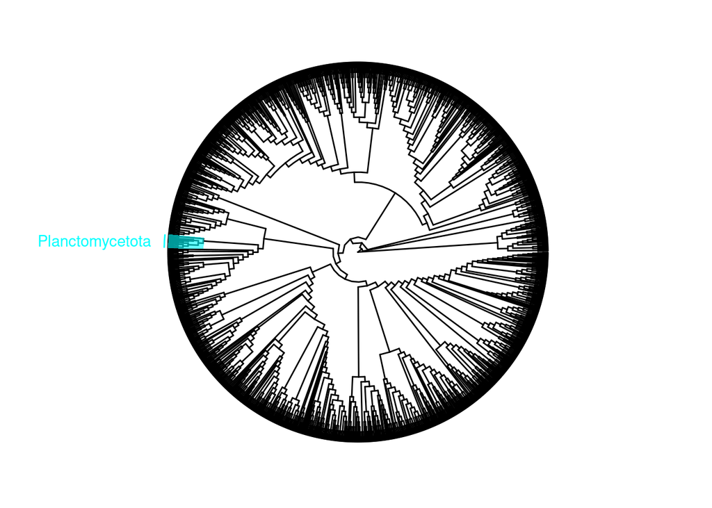

```r
ggtree(tree_bac, layout="circular", branch.length="none") +
    geom_hilight(node=2542, fill="cyan", alpha=.6) +
    geom_cladelab(node=2542, label="Planctomycetota", align=TRUE, hjust=1.1,
                  offset = 0, textcolor='cyan', barcolor='cyan')
```

##### Figure 1: Phylogenetic tree of the NEON data, with Planctomycetota labeled in cyan.

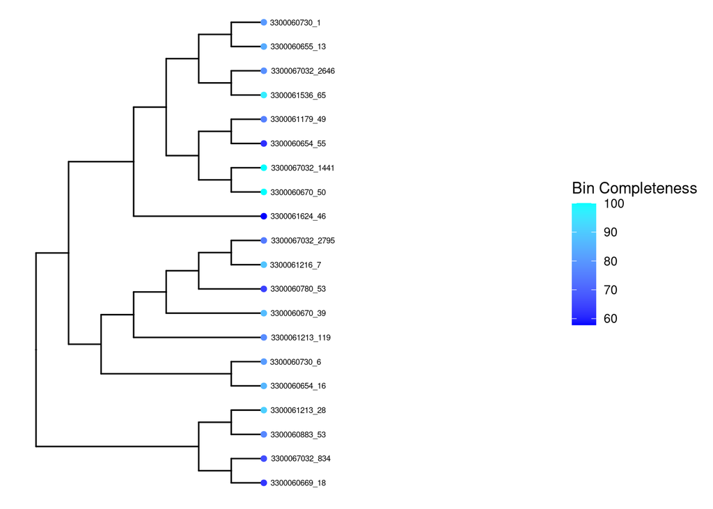

```r
ggtree(tree_Planctomycetota)  %<+%
  NEON_MAGs_metagenomes_chemistry +
  geom_tippoint(aes(colour=`Bin Completeness`)) +
  scale_colour_gradient(low='blue', high='cyan') +
  geom_tiplab(size=2, hjust=-.1) +
  xlim(0,15)
```

##### Figure 2: A look at the bin completeness of each sample within the Planctomycetota data.

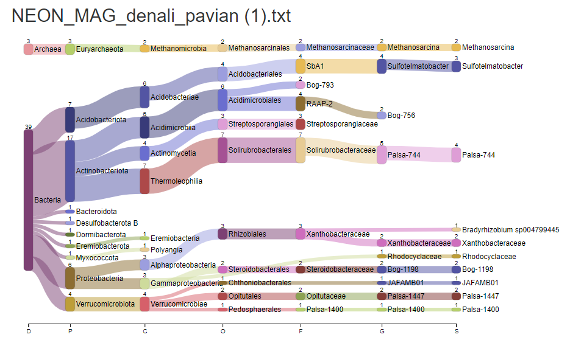

Figure 3: A taxonomic breakdown of the samples found at the Healy site

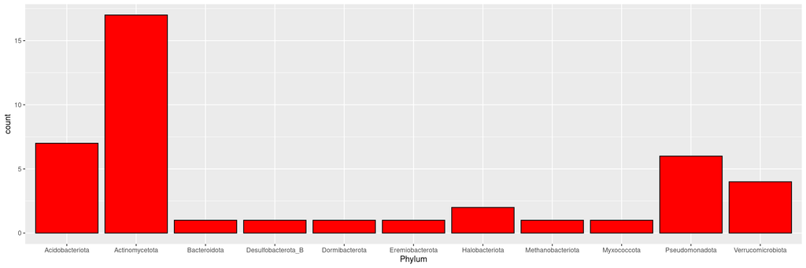

```r
ggplot(data = NEON_MAGs_HEAL, aes(x = `Phylum`)) +
  geom_bar(fill = "red", color = "black")
```

##### Figure 4: Counts of the different phylums found at the Healy site.

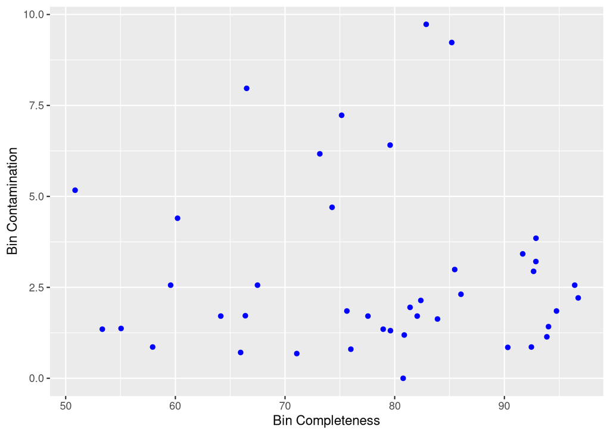

```r
ggplot(data = NEON_MAGs_HEAL, aes(x = `Bin Completeness`, y = `Bin Contamination`)) +
  geom_point(color = "blue")
```

##### Figure 5: A plot comparing the bin completeness versus the bin contamination for individual samples.

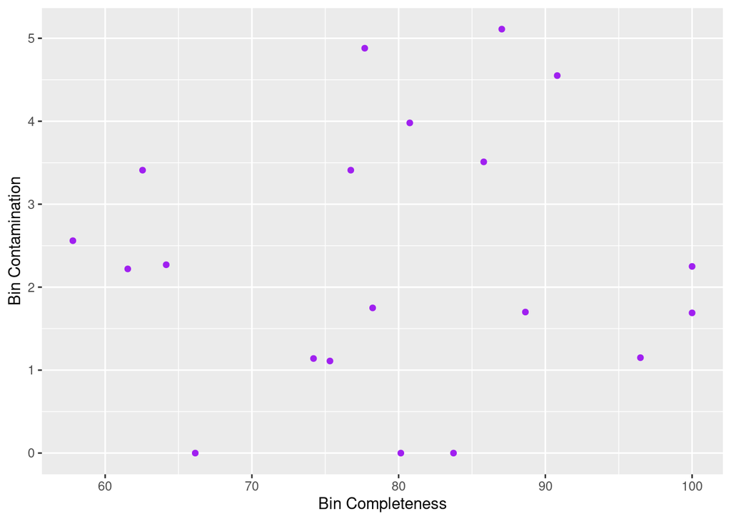

```r
ggplot(data = NEON_MAGs_Planctomycetota, aes(x = `Bin Completeness`, y = `Bin Contamination`)) +
  geom_point(color = "purple")
```

##### Figure 6: A plot comparing individual Planctomycetota sample’s bin completeness versus the bin contamination.

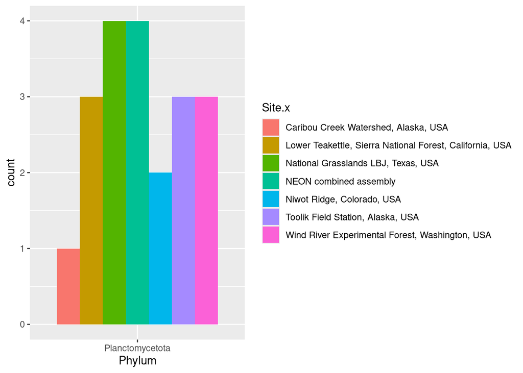

```r
NEON_MAGs_Planctomycetota %>%
ggplot(aes(x = Phylum, fill = Site.x)) +
  geom_bar(position = "dodge")
```

##### Figure 7: Planctomycetota counts at each NEON site.

```r
kable(
  NEON_MAGs_HEAL %>%
    count(Phylum, sort = TRUE)
)
```

| Phylum | n |
| --- | --- |
| Actinomycetota | 17 |
| Acidobacteriota | 7 |
| Pseudomonadota | 6 |
| Verrucomicrobiota | 4 |
| Halobacteriota | 2 |
| Bacteroidota | 1 |
| Desulfobacterota_B | 1 |
| Dormibacterota | 1 |
| Eremiobacterota | 1 |
| Methanobacteriota | 1 |
| Myxococcota | 1 |

##### Figure 8: Counts of each phylum found at the Healy site.

```r
kable(
  NEON_MAGs_Planctomycetota %>%
    count(siteID, sort = TRUE)
)
```

| siteID | n |
| --- | --- |
| CLBJ | 4 |
| NA | 4 |
| TEAK | 3 |
| TOOL | 3 |
| WREF | 3 |
| NIWO | 2 |
| BONA | 1 |

##### Figure 9: Counts of Planctomycetota samples found at each site.

## Discussion

Planctomycetota samples were found across several different biomes in the NEON data. This can likely be explained due to the phylum’s versatility. Members of the Planctomycetota phylum are found in a multitude of environments, both terrestrial and aquatic, so it makes sense that these samples would be encountered in many different sites.

Many of the phyla found at the Healy site mainly resided in soils. These phyla are very versatile, and capable of surviving in many different biome types. Given the harsh conditions present at the Healy site, it can be assumed that selection here favors generalist organisms, and this appears to be the case for the phyla in these samples (Li et al. 2014).

## Conclusion

“Confused about Bin Completion and Contamination.” n.d. Accessed May 20, 2024. https://www.biostars.org/p/9526318/.

“Healy NEON NSF NEON Open Data to Understand Our Ecosystems.” n.d. Accessed May 20, 2024. https://www.neonscience.org/field-sites/heal.

Li, Shuning, Richard Jovelin, Toyoshi Yoshiga, Ryusei Tanaka, and Asher D. Cutter. 2014. “Specialist Versus Generalist Life Histories and Nucleotide Diversity in Caenorhabditis Nematodes.” *Proceedings of the Royal Society B: Biological Sciences* 281 (1777): 20132858. https://doi.org/10.1098/rspb.2013.2858.

Osterkamp, T. E., M. T. Jorgenson, E. A. G. Schuur, Y. L. Shur, M. Z. Kanevskiy, J. G. Vogel, and V. E. Tumskoy. 2009. “Physical and Ecological Changes Associated with Warming Permafrost and Thermokarst in Interior Alaska.” *Permafrost and Periglacial Processes* 20 (3): 235–56. https://doi.org/10.1002/ppp.656.

“Planctomycetota.” 2024. *Wikipedia*. https://en.wikipedia.org/w/index.php?title=Planctomycetota&oldid=1208831841.